# quick-introduction-to-IntAssoPlot

This vignette documents usage of IntAssoPlot. IntAssoPlot was designed to plot the association, gene struture, and LD matrix in one single plot. As you read this document, you will see the input data format and the basic usage of IntAssoPlot.

## 1. input data format

### 1.1 association data format

A dataset containing the association file. The variables are as follows: Marker (molecular marker name), Locus (the chromosome of the marker), Site (the position of the marke), p (p value of the marker) Here’s a quick demo of association data format:

```r
head(association)
```

```
#>     Marker Locus     Site         p
#> 1 SNP37049     9 90042244 0.2073684
#> 2 SNP37050     9 90042408 0.5028760
#> 3 SNP37052     9 90210602 0.1561271
#> 4 SNP37053     9 90255652 0.2814653
#> 5 SNP37056     9 90290939 0.6392511
#> 6 SNP44597     9 90367887 0.6582597
```

```r
#the attribute of each column could be viewed as:
str(association$Marker)
```

```
#>  chr [1:2316] "SNP37049" "SNP37050" "SNP37052" "SNP37053" "SNP37056" ...
```

```r
str(association$Locus)
```

```
#>  int [1:2316] 9 9 9 9 9 9 9 9 9 9 ...
```

```r
str(association$Site)
```

```
#>  int [1:2316] 90042244 90042408 90210602 90255652 90290939 90367887 90377686 90385837 90560965 90759605 ...
```

```r
str(association$p)
```

```
#>  num [1:2316] 0.207 0.503 0.156 0.281 0.639 ...
```

### 1.2 gene structure data format

A dataset containing the annotation file, usually a gtf file, WITHOUT the column name. The annotation file could be read with header=FALSE. Here’s a quick demo of association data format:

```r
head(gtf)
```

```
#>   V1             V2          V3       V4       V5 V6 V7 V8
#> 1  9 protein_coding        exon 90030791 90030847  .  -  .
#> 2  9 protein_coding        exon 90030635 90030701  .  -  .
#> 3  9 protein_coding         CDS 90030635 90030681  .  -  0
#> 4  9 protein_coding start_codon 90030679 90030681  .  -  0
#> 5  9 protein_coding        exon 90029368 90029471  .  -  .
#> 6  9 protein_coding         CDS 90029368 90029471  .  -  1
#>                                                                                                             V9
#> 1                gene_id "GRMZM2G416644"; transcript_id "GRMZM2G416644_T01"; exon_number "1"; seqedit "false";
#> 2                gene_id "GRMZM2G416644"; transcript_id "GRMZM2G416644_T01"; exon_number "2"; seqedit "false";
#> 3 gene_id "GRMZM2G416644"; transcript_id "GRMZM2G416644_T01"; exon_number "2"; protein_id "GRMZM2G416644_P01";
#> 4                                 gene_id "GRMZM2G416644"; transcript_id "GRMZM2G416644_T01"; exon_number "2";
#> 5                gene_id "GRMZM2G416644"; transcript_id "GRMZM2G416644_T01"; exon_number "3"; seqedit "false";
#> 6 gene_id "GRMZM2G416644"; transcript_id "GRMZM2G416644_T01"; exon_number "3"; protein_id "GRMZM2G416644_P01";
```

```r
#the attribute of each column could be viewed as:
str(gtf$V1)
```

```
#>  chr [1:4665] "9" "9" "9" "9" "9" "9" "9" "9" "9" "9" "9" "9" "9" "9" "9" ...
```

```r
str(gtf$V2)
```

```
#>  chr [1:4665] "protein_coding" "protein_coding" "protein_coding" ...
```

```r
str(gtf$V3)
```

```
#>  chr [1:4665] "exon" "exon" "CDS" "start_codon" "exon" "CDS" "exon" "CDS" ...
```

```r
str(gtf$V4)
```

```
#>  int [1:4665] 90030791 90030635 90030635 90030679 90029368 90029368 90028806 90029227 90029224 90030697 ...
```

```r
str(gtf$V5)
```

```
#>  int [1:4665] 90030847 90030701 90030681 90030681 90029471 90029471 90029282 90029282 90029226 90031013 ...
```

```r
str(gtf$V6)
```

```
#>  chr [1:4665] "." "." "." "." "." "." "." "." "." "." "." "." "." "." "." ...
```

```r
str(gtf$V7)
```

```
#>  chr [1:4665] "-" "-" "-" "-" "-" "-" "-" "-" "-" "-" "-" "-" "-" "-" "-" ...
```

```r
str(gtf$V8)
```

```
#>  chr [1:4665] "." "." "0" "0" "." "1" "." "2" "0" "." "0" "0" "." "0" "0" ...
```

```r
str(gtf$V9)
```

```
#>  chr [1:4665] "gene_id \"GRMZM2G416644\"; transcript_id \"GRMZM2G416644_T01\"; exon_number \"1\"; seqedit \"false\";" ...
```

### 1.3 genotype data format

A dataset containing the genotype file, usually a hapmap file, with the column name. Here’s a quick demo of association data format:

```r
#only 20 column of the genotype markers are shown.
head(zmvpp1_hapmap[,1:20])
```

```
#>          rs allele chrom      pos strand assembly center protLSID assayLSID
#> 1 INDEL-665    -/+     9 94183611      +       NA     NA       NA        NA
#> 2   snp-663    A/T     9 94183597      +       NA     NA       NA        NA
#> 3   snp-649    A/G     9 94183594      +       NA     NA       NA        NA
#> 4   snp-646    C/T     9 94183585      +       NA     NA       NA        NA
#> 5   snp-637    G/T     9 94183584      +       NA     NA       NA        NA
#> 6   snp-636    A/G     9 94183575      +       NA     NA       NA        NA
#>   panel QCcode B73 CIMBL55 CIMBL32 CML298 CML170 CIMBL12 CIMBL95 CIMBL1 CIMBL56
#> 1    NA     NA  --      ++      ++     ++     ++      ++      ++     --      --
#> 2    NA     NA  AA      TT      TT     TT     TT      TT      TT     NN      NN
#> 3    NA     NA  AA      GG      GG     GG     GG      GG      GG     NN      NN
#> 4    NA     NA  CC      TT      TT     TT     TT      TT      TT     NN      NN
#> 5    NA     NA  GG      TT      TT     TT     TT      TT      TT     NN      NN
#> 6    NA     NA  AA      AA      AA     AA     AA      AA      AA     NN      NN
```

## 2. plot the association with annotation and LD matrix

Here, we present an example to show the usage of IntAssoPlot, using a previouly published data (Wang, et al., 2016)

### 2.1 Regional integrative plot with one set of genotype markers

plot the association results at a region spaning a 400 kbp region, and plot the LD matrix using SNP markerers that are same as that for association mapping.

```
#> Linkage Disequilibrium (LD) estimation on genotypes:
#> Working space: 368 samples, 270 SNPs
#>     using 1 (CPU) core.
#>     method: correlation
#> LD matrix:    the sum of all selected genotypes (0,1,2) = 143276
#> Linkage Disequilibrium (LD) estimation on genotypes:
#> Working space: 368 samples, 270 SNPs
#>     using 1 (CPU) core.
#>     method: correlation
#> LD matrix:    the sum of all selected genotypes (0,1,2) = 143276
```

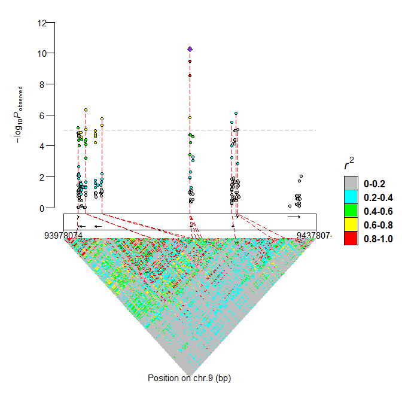

```r
IntRegionalPlot(chr=9,left=94178074-200000,right=94178074+200000,gtf=gtf,association=association,hapmap=hapmap_am368,hapmap_ld=hapmap_am368,threshold=5,leadsnp_size=2)
```

### 2.2 plot the LD values with colours ranging from light gray to dark gray.

```
#> Linkage Disequilibrium (LD) estimation on genotypes:
#> Working space: 368 samples, 270 SNPs
#>     using 1 (CPU) core.
#>     method: correlation
#> LD matrix:    the sum of all selected genotypes (0,1,2) = 143276
#> Linkage Disequilibrium (LD) estimation on genotypes:
#> Working space: 368 samples, 270 SNPs
#>     using 1 (CPU) core.
#>     method: correlation
#> LD matrix:    the sum of all selected genotypes (0,1,2) = 143276
```

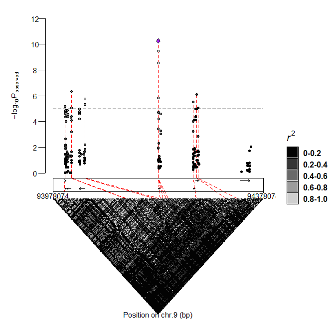

```r
IntRegionalPlot(chr=9,left=94178074-200000,right=94178074+200000,gtf=gtf,association=association,hapmap=hapmap_am368,hapmap_ld=hapmap_am368,threshold=5,leadsnp_size=2,colour02 = "gray1",colour04 = "gray21",colour06 = "gray41",colour08 = "gray61",colour10 = "gray81",)
```

### 2.3 plot the LD values with colours ranging from white to red.

```
#> Linkage Disequilibrium (LD) estimation on genotypes:
#> Working space: 368 samples, 270 SNPs
#>     using 1 (CPU) core.
#>     method: correlation
#> LD matrix:    the sum of all selected genotypes (0,1,2) = 143276
#> Linkage Disequilibrium (LD) estimation on genotypes:
#> Working space: 368 samples, 270 SNPs
#>     using 1 (CPU) core.
#>     method: correlation
#> LD matrix:    the sum of all selected genotypes (0,1,2) = 143276
```

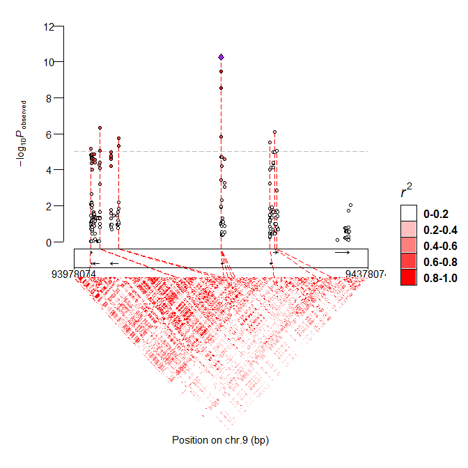

```r
#get five colors ranging from white to red
pal <- colorRampPalette(c("white", "red"))
IntRegionalPlot(chr=9,left=94178074-200000,right=94178074+200000,gtf=gtf,association=association,hapmap=hapmap_am368,hapmap_ld=hapmap_am368,threshold=5,leadsnp_size=2,colour02 = pal(5)[1],colour04 = pal(5)[2],colour06 = pal(5)[3],colour08 = pal(5)[4],colour10 = pal(5)[5])
```

### 2.4 plot the LD values with colours ranging from white to red and label the gene name.

```
#> Linkage Disequilibrium (LD) estimation on genotypes:
#> Working space: 368 samples, 270 SNPs
#>     using 1 (CPU) core.
#>     method: correlation
#> LD matrix:    the sum of all selected genotypes (0,1,2) = 143276
#> Linkage Disequilibrium (LD) estimation on genotypes:
#> Working space: 368 samples, 270 SNPs
#>     using 1 (CPU) core.
#>     method: correlation
#> LD matrix:    the sum of all selected genotypes (0,1,2) = 143276
```

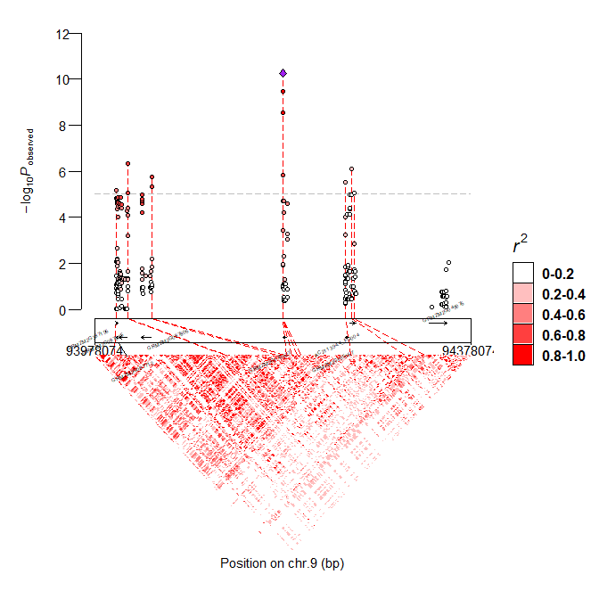

```r
#get five colors ranging from white to red
pal <- colorRampPalette(c("white", "red"))
IntRegionalPlot(chr=9,left=94178074-200000,right=94178074+200000,gtf=gtf,association=association,hapmap=hapmap_am368,hapmap_ld=hapmap_am368,threshold=5,leadsnp_size=2,colour02 = pal(5)[1],colour04 = pal(5)[2],colour06 = pal(5)[3],colour08 = pal(5)[4],colour10 = pal(5)[5],label_gene_name = TRUE)
```

### 2.5 Regional integrative plot with two set of genotype markers

plot the association results at a regional spaning a 200 kbp region, and plot the LD matrix using SNP markerers that differed from that for association mapping. This feature allows reserchers investigate the LD structure at a more wide range of markers.

```
#> Linkage Disequilibrium (LD) estimation on genotypes:
#> Working space: 368 samples, 108 SNPs
#>     using 1 (CPU) core.
#>     method: correlation
#> LD matrix:    the sum of all selected genotypes (0,1,2) = 56746
#> Linkage Disequilibrium (LD) estimation on genotypes:
#> Working space: 104 samples, 1081 SNPs
#>     using 1 (CPU) core.
#>     method: correlation
#> LD matrix:    the sum of all selected genotypes (0,1,2) = 114672
```

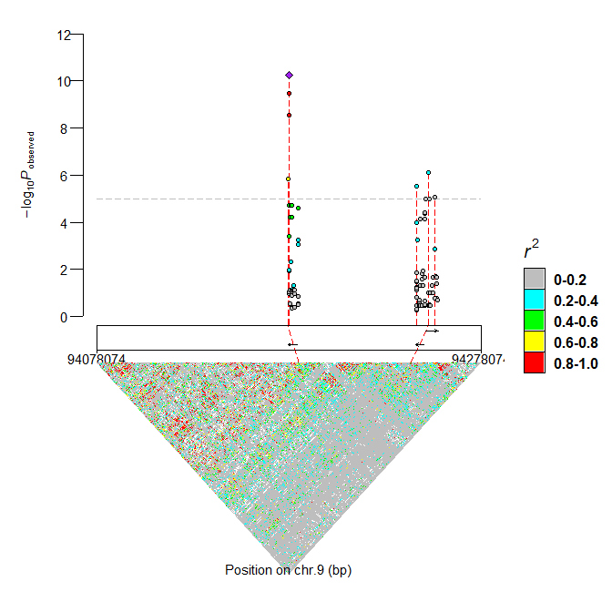

```r
IntRegionalPlot(chr=9,left=94178074-100000,right=94178074+100000,gtf=gtf,association=association,hapmap=hapmap_am368,hapmap_ld=hapmap2,threshold=5,leadsnp_size=2)
```

### 2.6 a relative small regional integrative plot with one set of genotype markers

plot the association results at a regional covering the candidate gene, and plot the LD matrix using SNP markerers that are the same from that for association mapping.

```
#> Linkage Disequilibrium (LD) estimation on genotypes:
#> Working space: 368 samples, 41 SNPs
#>     using 1 (CPU) core.
#>     method: correlation
#> LD matrix:    the sum of all selected genotypes (0,1,2) = 21412
#> Linkage Disequilibrium (LD) estimation on genotypes:
#> Working space: 368 samples, 41 SNPs
#>     using 1 (CPU) core.
#>     method: correlation
#> LD matrix:    the sum of all selected genotypes (0,1,2) = 21412
```

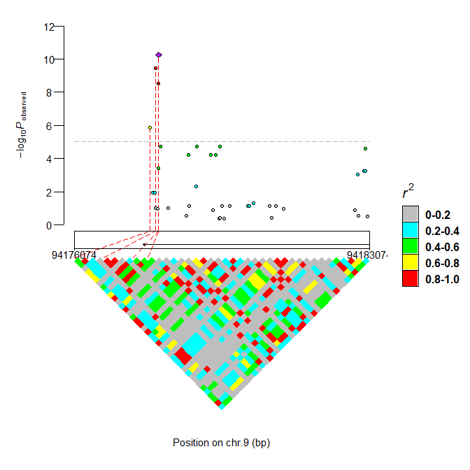

```r
IntRegionalPlot(chr=9,left=94178074-2000,right=94178074+5000,gtf=gtf,association=association,hapmap=hapmap_am368,hapmap_ld=hapmap_am368,threshold=5,leadsnp_size=2)
```

### 2.7 a single gene level plot

plot the association results at a given gene, and plot the LD matrix using SNP markerers that are the same from that for association mapping. Also specified markers are highlighted by various shape and colour.

#### 2.7.1 a basic plot

```
#> Linkage Disequilibrium (LD) estimation on genotypes:
#> Working space: 141 samples, 53 SNPs
#>     using 1 (CPU) core.
#>     method: correlation
#> LD matrix:    the sum of all selected genotypes (0,1,2) = 9992
#> Linkage Disequilibrium (LD) estimation on genotypes:
#> Working space: 141 samples, 53 SNPs
#>     using 1 (CPU) core.
#>     method: correlation
#> LD matrix:    the sum of all selected genotypes (0,1,2) = 9992
```

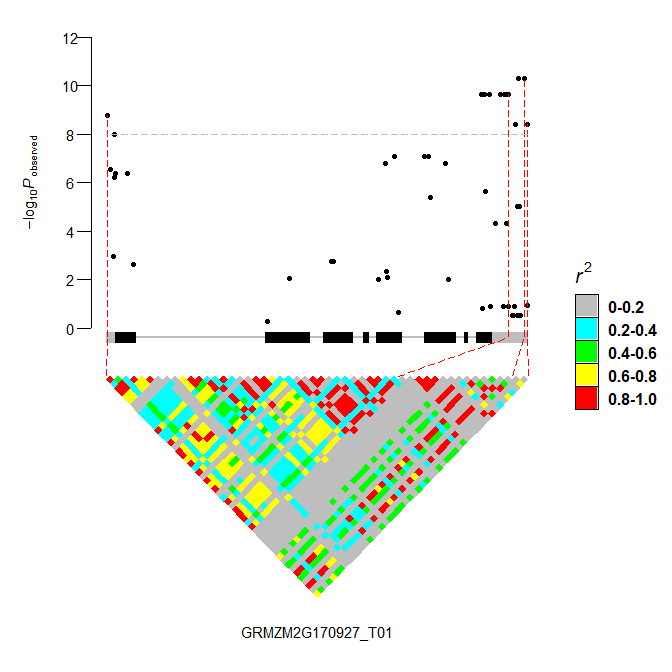

```r
IntGenicPlot('GRMZM2G170927_T01',gtf,association=zmvpp1_association,hapmap=zmvpp1_hapmap,hapmap_ld = zmvpp1_hapmap,threshold=8,leadsnpLD = FALSE)
```

#### 2.7.2 extand region from up/down-stream of gene

```
#> Linkage Disequilibrium (LD) estimation on genotypes:
#> Working space: 141 samples, 124 SNPs
#>     using 1 (CPU) core.
#>     method: correlation
#> LD matrix:    the sum of all selected genotypes (0,1,2) = 23488
#> Linkage Disequilibrium (LD) estimation on genotypes:
#> Working space: 141 samples, 124 SNPs
#>     using 1 (CPU) core.
#>     method: correlation
#> LD matrix:    the sum of all selected genotypes (0,1,2) = 23488
```

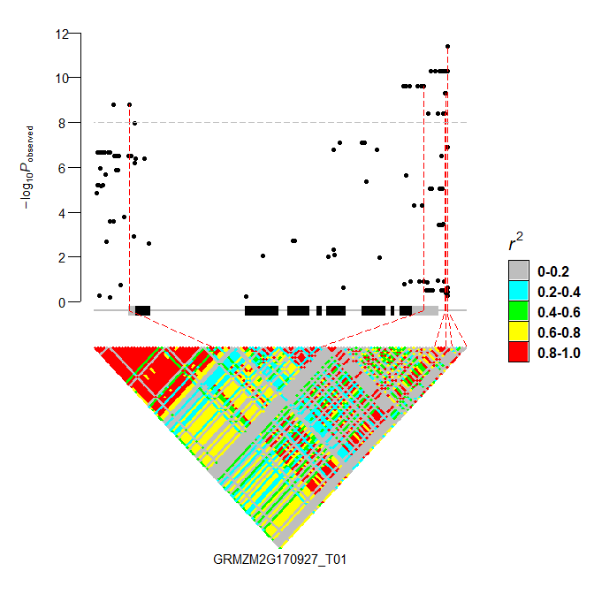

```r
IntGenicPlot('GRMZM2G170927_T01',gtf,association=zmvpp1_association,hapmap=zmvpp1_hapmap,hapmap_ld = zmvpp1_hapmap,threshold=8,up=500,down=600,leadsnpLD = FALSE)
```

#### 2.7.3 highlight selected marker, with colour and shape speicified in a dataframe: marker2highlight

```
#> Linkage Disequilibrium (LD) estimation on genotypes:
#> Working space: 141 samples, 124 SNPs
#>     using 1 (CPU) core.
#>     method: correlation
#> LD matrix:    the sum of all selected genotypes (0,1,2) = 23488
#> Linkage Disequilibrium (LD) estimation on genotypes:
#> Working space: 141 samples, 124 SNPs
#>     using 1 (CPU) core.
#>     method: correlation
#> LD matrix:    the sum of all selected genotypes (0,1,2) = 23488
```

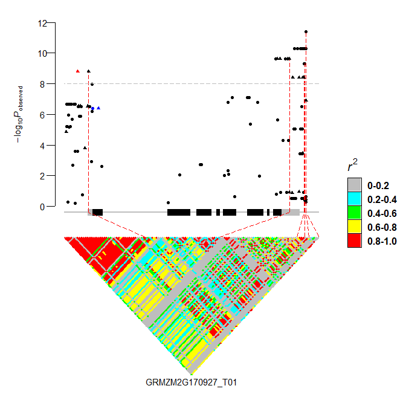

```r
IntGenicPlot('GRMZM2G170927_T01',gtf,association=zmvpp1_association,hapmap=zmvpp1_hapmap,hapmap_ld = zmvpp1_hapmap,threshold=8,up=500,down=600,leadsnpLD = FALSE,marker2highlight=marker2highlight)
```

#### 2.7.4 add linking line

```
#> Linkage Disequilibrium (LD) estimation on genotypes:
#> Working space: 141 samples, 124 SNPs
#>     using 1 (CPU) core.
#>     method: correlation
#> LD matrix:    the sum of all selected genotypes (0,1,2) = 23488
#> Linkage Disequilibrium (LD) estimation on genotypes:
#> Working space: 141 samples, 124 SNPs
#>     using 1 (CPU) core.
#>     method: correlation
#> LD matrix:    the sum of all selected genotypes (0,1,2) = 23488
```

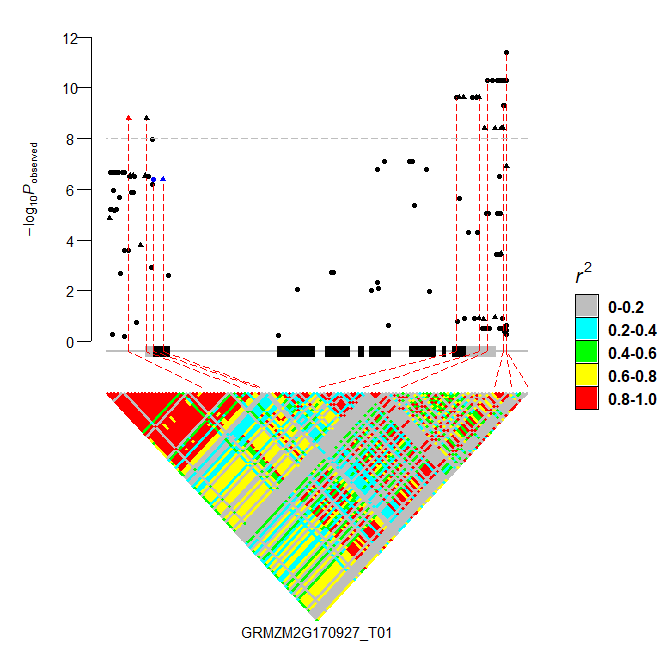

```r
IntGenicPlot('GRMZM2G170927_T01',gtf,association=zmvpp1_association,hapmap=zmvpp1_hapmap,hapmap_ld = zmvpp1_hapmap,threshold=8,up=500,down=600,leadsnpLD = FALSE,marker2highlight=marker2highlight,link2gene=marker2link,link2LD=marker2link)
```

#### 2.7.5 add names for highlighted marker

```
#> Linkage Disequilibrium (LD) estimation on genotypes:
#> Working space: 141 samples, 124 SNPs
#>     using 1 (CPU) core.
#>     method: correlation
#> LD matrix:    the sum of all selected genotypes (0,1,2) = 23488
#> Linkage Disequilibrium (LD) estimation on genotypes:
#> Working space: 141 samples, 124 SNPs
#>     using 1 (CPU) core.
#>     method: correlation
#> LD matrix:    the sum of all selected genotypes (0,1,2) = 23488
```

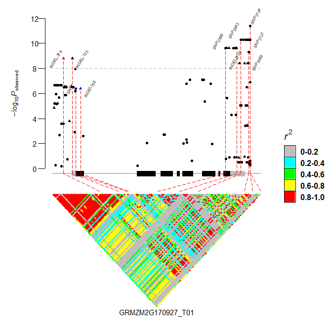

```r
IntGenicPlot('GRMZM2G170927_T01',gtf,association=zmvpp1_association,hapmap=zmvpp1_hapmap,hapmap_ld = zmvpp1_hapmap,threshold=8,up=500,down=600,leadsnpLD = FALSE,marker2highlight=marker2highlight,link2gene=marker2link,link2LD=marker2link,marker2label=marker2link,marker2label_angle=60,marker2label_size=2)
```